# Lab 3: School Districting

In this lab, we will investigate school districting.

For Lab 3, submit your **HTML** to **CANVAS** :)

```python
import geopandas as gpd
import matplotlib.pyplot as plt
import gurobipy as gp
from gurobipy import GRB
import numpy as np
from matplotlib_scalebar.scalebar import ScaleBar

from shapely.geometry import LineString
import matplotlib.lines as mlines
import pandas as pd
pd.set_option('display.max_rows', 500)

import folium
from folium import plugins
```

## Step 1: Data Preparation

```python
# Import the blocks.shp and hope.shp in the Data folder!

# blocks.shp contains the blocks in the census tracts which intersects with the Hope Elementary School District
blocks = gpd.read_file("Data/blocks.shp")
# hope.shp contains one geometry of the Hope Elementary School district
hope = gpd.read_file("Data/hope.shp")
```

#### Question 1. Plot both the blocks GeoDataFrame and the hope GeoDataFrame in a single figure. ( 1 pt )

*Hint: They wouldn't be aligned together automatically!*

**Grading Rubric**

- Ensure that hope is on top of blocks ( +0.5 )
- Ensure that hope has distinguishable edgecolor, but no facecolor ( +0.5 )

```python
blocks = blocks.to_crs("epsg:3857")
```

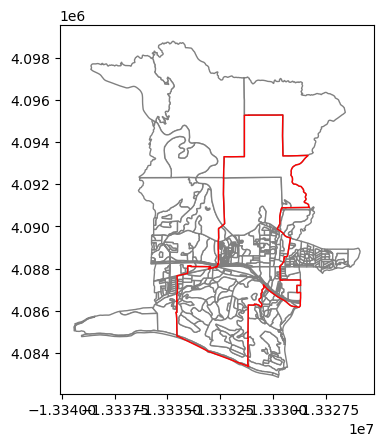

```python
fig , ax = plt.subplots(1,1)

# plot the background blocks
blocks.plot(ax=ax, facecolor = "white", edgecolor='grey')
# plot your foreground hope district
hope.plot(ax=ax, facecolor = "none", edgecolor='red' )
```

#### Question 2. Plot the "elpop" column of the blocks DataFrame, which represents the elementary student population of each block. ( 1 pt )

**Grading Rubric**

- Title and Legend are provided, legend is numeric ( +0.5 )
- Scalebar and Axis information is provided ( +0.5 )

**Note:** Only 5-9 years old children population in the block is included in the dataset.  
As decennial census provides the age ranges 5-9, 10-14, 14-19 and so on.  
Refer to this webpage to learn more. https://api.census.gov/data/2020/dec/dhc/variables.html  
Also, you can refer to dataprep.ipynb file to see how the lab data is prepared!

```
<matplotlib_scalebar.scalebar.ScaleBar at 0x7fbf79289190>
```

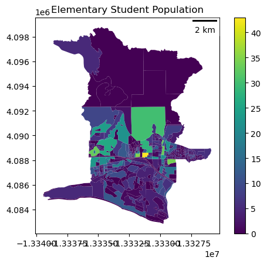

```python
ax = blocks.plot(column = 'elpop',
                  legend=True,
                 )
plt.title('Elementary Student Population')
scalebar = ScaleBar(1)
ax.add_artist(scalebar)
```

#### Question 3: Subset the blocks GeoDataFrame to include only the blocks within the Hope Elementary School District, and assign this subset to the variable named "blocks". ( 1 pt )

*So.. you are updating the existing variable, "blocks"*

*Hint:* Visualize the output of the blocks GeoDataFrame by plotting it alongside the hope GeoDataFrame to verify if all the blocks within the Hope School District have been included.

If some blocks are missing, you can ensure you have all the necessary blocks by cross-referencing the spatial extent of the blocks GeoDataFrame with the boundaries of the Hope School District defined in the hope GeoDataFrame.  
Ensure that the spatial query used to subset the blocks properly captures all the relevant blocks within the district's boundaries.

**NOTE: Every time taking a subset, don't forget to "RESET_INDEX()" !!**

```python
blocks.reset_index(drop=True, inplace=True)
hope.reset_index(drop=True, inplace=True)

hope_boundary = hope.unary_union

# Perform the spatial operation to find blocks within the hope boundary
blocks = blocks[blocks.geometry.within(hope_boundary)]
blocks
```

|  | STATEFP20 | COUNTYFP20 | TRACTCE20 | BLOCKCE20 | GEOID20 | NAME20 | MTFCC20 | UR20 | UACE20 | UATYPE20 | ... | ALAND20 | AWATER20 | INTPTLAT20 | INTPTLON20 | HOUSING20 | POP20 | elpop | elwpop | curr_assig | geometry |
| --- | --- | --- | --- | --- | --- | --- | --- | --- | --- | --- | --- | --- | --- | --- | --- | --- | --- | --- | --- | --- | --- |
| 1 | 06 | 083 | 000102 | 4007 | 060830001024007 | Block 4007 | G5040 | U | 79282 | U | ... | 34984 | 0 | +34.4500674 | -119.7603649 | 0 | 0 | 0 | 0 | 2 | POLYGON ((-13331778.287 4089573.029, -13331763... |
| 5 | 06 | 083 | 000202 | 2004 | 060830002022004 | Block 2004 | G5040 | U | 79282 | U | ... | 9763 | 0 | +34.4381334 | -119.7431966 | 79 | 144 | 9 | 0 | 2 | POLYGON ((-13329807.042 4087849.788, -13329694... |
| 9 | 06 | 083 | 003005 | 2009 | 060830030052009 | Block 2009 | G5040 | U | 79282 | U | ... | 58465 | 0 | +34.4379447 | -119.7719099 | 26 | 54 | 12 | 12 | 2 | POLYGON ((-13333070.373 4087683.228, -13333065... |
| 16 | 06 | 083 | 000101 | 4004 | 060830001014004 | Block 4004 | G5040 | U | 79282 | U | ... | 4439 | 0 | +34.4453001 | -119.7640170 | 7 | 10 | 0 | 0 | 2 | POLYGON ((-13332117.700 4088785.619, -13332057... |
| 23 | 06 | 083 | 003007 | 3022 | 060830030073022 | Block 3022 | G5040 | U | 79282 | U | ... | 53467 | 0 | +34.4261918 | -119.7592283 | 11 | 9 | 0 | 0 | 2 | POLYGON ((-13331668.081 4086104.138, -13331664... |
| 24 | 06 | 083 | 000502 | 6005 | 060830005026005 | Block 6005 | G5040 | U | 79282 | U | ... | 132836 | 0 | +34.4466891 | -119.7433645 | 127 | 303 | 33 | 29 | 2 | POLYGON ((-13329926.710 4088412.789, -13329919... |
| 25 | 06 | 083 | 000202 | 2014 | 060830002022014 | Block 2014 | G5040 | U | 79282 | U | ... | 8659 | 0 | +34.4375325 | -119.7526469 | 0 | 0 | 0 | 0 | 2 | POLYGON ((-13330973.336 4087917.952, -13330783... |
| 26 | 06 | 083 | 000101 | 1006 | 060830001011006 | Block 1006 | G5040 | U | 79282 | U | ... | 4277 | 0 | +34.4419527 | -119.7657291 | 12 | 33 | 2 | 0 | 2 | POLYGON ((-13332287.908 4088358.121, -13332285... |
| 27 | 06 | 083 | 003005 | 2012 | 060830030052012 | Block 2012 | G5040 | U | 79282 | U | ... | 138334 | 0 | +34.4345101 | -119.7792255 | 67 | 190 | 7 | 2 | 2 | POLYGON ((-13334286.649 4087078.019, -13334281... |
| 35 | 06 | 083 | 000502 | 6003 | 060830005026003 | Block 6003 | G5040 | U | 79282 | U | ... | 47619 | 0 | +34.4477600 | -119.7415924 | 44 | 126 | 4 | 2 | 2 | POLYGON ((-13329644.849 4088890.640, -13329636... |
| 37 | 06 | 083 | 003005 | 2013 | 060830030052013 | Block 2013 | G5040 | U | 79282 | U | ... | 50754 | 0 | +34.4356208 | -119.7819483 | 31 | 56 | 1 | 0 | 2 | POLYGON ((-13334277.633 4087391.282, -13334273... |
| 39 | 06 | 083 | 003007 | 3023 | 060830030073023 | Block 3023 | G5040 | U | 79282 | U | ... | 100205 | 0 | +34.4257931 | -119.7736597 | 10 | 14 | 0 | 0 | 2 | POLYGON ((-13333347.558 4086209.943, -13333341... |
| 40 | 06 | 083 | 003007 | 3017 | 060830030073017 | Block 3017 | G5040 | U | 79282 | U | ... | 69197 | 0 | +34.4276637 | -119.7825573 | 7 | 33 | 4 | 0 | 2 | POLYGON ((-13334536.896 4086414.945, -13334503... |
| 41 | 06 | 083 | 003005 | 2005 | 060830030052005 | Block 2005 | G5040 | U | 79282 | U | ... | 28525 | 0 | +34.4336051 | -119.7847704 | 22 | 70 | 3 | 0 | 2 | POLYGON ((-13334472.998 4087278.582, -13334468... |
| 44 | 06 | 083 | 000502 | 6000 | 060830005026000 | Block 6000 | G5040 | U | 79282 | U | ... | 24120 | 0 | +34.4529729 | -119.7438500 | 17 | 60 | 11 | 9 | 2 | POLYGON ((-13329989.828 4090026.359, -13329913... |
| 45 | 06 | 083 | 003005 | 2010 | 060830030052010 | Block 2010 | G5040 | U | 79282 | U | ... | 94849 | 0 | +34.4378693 | -119.7693407 | 37 | 130 | 6 | 3 | 2 | POLYGON ((-13332858.532 4087675.670, -13332850... |
| 46 | 06 | 083 | 003007 | 2002 | 060830030072002 | Block 2002 | G5040 | U | 79282 | U | ... | 13608 | 0 | +34.4372366 | -119.7580271 | 18 | 36 | 1 | 0 | 2 | POLYGON ((-13331547.856 4087705.634, -13331496... |
| 47 | 06 | 083 | 000102 | 4011 | 060830001024011 | Block 4011 | G5040 | U | 79282 | U | ... | 2415 | 0 | +34.4494119 | -119.7595427 | 4 | 11 | 0 | 0 | 2 | POLYGON ((-13331600.955 4089325.852, -13331600... |
| 48 | 06 | 083 | 000101 | 1009 | 060830001011009 | Block 1009 | G5040 | U | 79282 | U | ... | 5741 | 0 | +34.4421711 | -119.7661815 | 18 | 52 | 0 | 0 | 2 | POLYGON ((-13332338.447 4088380.528, -13332337... |
| 51 | 06 | 083 | 003007 | 3000 | 060830030073000 | Block 3000 | G5040 | U | 79282 | U | ... | 9594 | 0 | +34.4352655 | -119.7507724 | 0 | 0 | 0 | 0 | 2 | POLYGON ((-13330755.595 4087547.175, -13330687... |
| 52 | 06 | 083 | 003007 | 3003 | 060830030073003 | Block 3003 | G5040 | U | 79282 | U | ... | 39915 | 0 | +34.4299042 | -119.7533283 | 9 | 22 | 0 | 0 | 2 | POLYGON ((-13331027.437 4086690.535, -13331009... |
| 53 | 06 | 083 | 003007 | 2007 | 060830030072007 | Block 2007 | G5040 | U | 79282 | U | ... | 108235 | 0 | +34.4338770 | -119.7750419 | 38 | 67 | 0 | 0 | 2 | POLYGON ((-13334290.323 4087020.658, -13334271... |
| 57 | 06 | 083 | 003007 | 3024 | 060830030073024 | Block 3024 | G5040 | U | 79282 | U | ... | 309473 | 0 | +34.4230589 | -119.7755258 | 23 | 84 | 6 | 3 | 2 | POLYGON ((-13333880.890 4086013.718, -13333878... |
| 60 | 06 | 083 | 000102 | 4012 | 060830001024012 | Block 4012 | G5040 | U | 79282 | U | ... | 10221 | 0 | +34.4483248 | -119.7523048 | 15 | 39 | 5 | 5 | 2 | POLYGON ((-13330907.324 4089170.610, -13330903... |
| 61 | 06 | 083 | 003007 | 3021 | 060830030073021 | Block 3021 | G5040 | U | 79282 | U | ... | 48248 | 0 | +34.4222689 | -119.7682045 | 8 | 25 | 2 | 2 | 2 | POLYGON ((-13332828.921 4085626.675, -13332808... |
| 62 | 06 | 083 | 000101 | 4016 | 060830001014016 | Block 4016 | G5040 | U | 79282 | U | ... | 5969 | 0 | +34.4447225 | -119.7601646 | 0 | 0 | 0 | 0 | 2 | POLYGON ((-13331670.864 4088747.012, -13331641... |
| 63 | 06 | 083 | 000101 | 4017 | 060830001014017 | Block 4017 | G5040 | U | 79282 | U | ... | 73175 | 0 | +34.4426976 | -119.7616246 | 72 | 266 | 35 | 6 | 2 | POLYGON ((-13331999.590 4088230.833, -13331999... |
| 66 | 06 | 083 | 003007 | 3020 | 060830030073020 | Block 3020 | G5040 | U | 79282 | U | ... | 30006 | 0 | +34.4262544 | -119.7642074 | 7 | 14 | 0 | 0 | 2 | POLYGON ((-13332178.147 4086066.755, -13332151... |
| 67 | 06 | 083 | 000102 | 1006 | 060830001021006 | Block 1006 | G5040 | U | 79282 | U | ... | 43921 | 0 | +34.4523411 | -119.7478052 | 38 | 92 | 3 | 3 | 2 | POLYGON ((-13330401.599 4089720.042, -13330402... |
| 68 | 06 | 083 | 000101 | 4010 | 060830001014010 | Block 4010 | G5040 | U | 79282 | U | ... | 7624 | 0 | +34.4488166 | -119.7619013 | 14 | 23 | 0 | 0 | 2 | POLYGON ((-13331932.576 4089196.124, -13331928... |

[output cut: 147 more lines]

177 rows × 21 columns

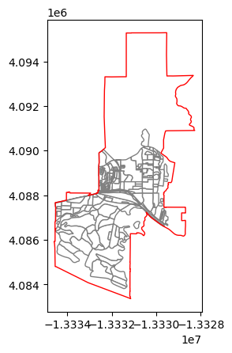

```python
fig , ax = plt.subplots(1,1)

# plot the background blocks
blocks.plot(ax=ax, facecolor = "white", edgecolor='grey')
# plot your foreground hope district
hope.plot(ax=ax, facecolor = "none", edgecolor='red' )
```

```python
# Ensure to print this out, so I can grade!
len(blocks)
```

```
177
```

#### Question 4: Calculate the total elementary student population within the Hope Elementary School District. ( 1 pt )

```python
hope_elpop = blocks.elpop.sum()
hope_elpop
```

```
693
```

#### Question 5: Find the fraction of white-only students among the total elementary student population within the Hope Elementary School District. ( 1 pt )

```python
hope_elpop_share_white = blocks.elwpop.sum() / blocks.elpop.sum()
hope_elpop_share_white
```

```
0.4531024531024531
```

#### Question 6: Create a new variable, "schools", containing only the schools managed by the Hope Elementary School District. ( 2 pts )

**Steps:**

1. Download the California school point location shapefile from this data source (https://gis.data.ca.gov/datasets/f7f818b0aa7a415192eaf66f192bc9cc/explore)
2. Locate the file in Data folder and read the shapefile in this notebook
3. Take a subset of the file by only including schools within the hope GeoDataFrame ( +1 )
4. Take another subset, which only includes school that are part of Hope Elementary School district. Assign the subset to a variable, "schools" ( +1 )

**NOTE: Every time taking a subset, don't forget to "RESET_INDEX()" !!**

*Hint*  
Look into this webpage. (https://www.hopeschooldistrict.org/en-US/schools)  
Hope Elementary school district only includes three elementary schools.  
Make sure that your schools GeoDataFrame includes only the three elementary schools

```python
schools = gpd.read_file("Data/SchoolSites2019_20/SchoolSites1920.shp")
```

```python
schools.crs
```

```
<Projected CRS: EPSG:3857>
Name: WGS 84 / Pseudo-Mercator
Axis Info [cartesian]:
- X[east]: Easting (metre)
- Y[north]: Northing (metre)
Area of Use:
- name: World between 85.06°S and 85.06°N.
- bounds: (-180.0, -85.06, 180.0, 85.06)
Coordinate Operation:
- name: Popular Visualisation Pseudo-Mercator
- method: Popular Visualisation Pseudo Mercator
Datum: World Geodetic System 1984 ensemble
- Ellipsoid: WGS 84
- Prime Meridian: Greenwich
```

```python
schools = schools[schools.geometry.within(hope_boundary)]
schools = schools.loc[schools['SchoolType'] == "Elementary"]
```

```python
# Run this cell to print out your schools
schools
```

|  | Year | FedID | CDSCode | CDCode | SCode | CountyName | DistrictNa | SchoolName | SchoolType | Status | ... | HOMpct | MIGcount | MIGpct | SEDCount | SEDpct | SWDcount | SWDpct | FRPMcount | FRPMpct | geometry |
| --- | --- | --- | --- | --- | --- | --- | --- | --- | --- | --- | --- | --- | --- | --- | --- | --- | --- | --- | --- | --- | --- |
| 8241 | 2019-20 | 061749007426 | 42692116045538 | 4269211 | 6045538 | Santa Barbara | Hope Elementary | Hope Elementary | Elementary | Active | ... | 1.0 | 0 | 0.0 | 116 | 37.5 | 39 | 12.6 | 111 | 35.9 | POINT (-13330987.696 4088677.224) |
| 8242 | 2019-20 | 061749002189 | 42692116045546 | 4269211 | 6045546 | Santa Barbara | Hope Elementary | Monte Vista Elementary | Elementary | Active | ... | 0.3 | 0 | 0.0 | 77 | 25.2 | 28 | 9.2 | 77 | 25.2 | POINT (-13330040.367 4089457.472) |
| 8243 | 2019-20 | 061749002190 | 42692116045553 | 4269211 | 6045553 | Santa Barbara | Hope Elementary | Vieja Valley Elementary | Elementary | Active | ... | 0.0 | 0 | 0.0 | 99 | 31.1 | 23 | 7.2 | 97 | 30.5 | POINT (-13332674.187 4087471.860) |

3 rows × 68 columns

```
(-13334797.322012618,
 -13329207.536233876,
 4083459.7999106767,
 4091321.332675813)
```

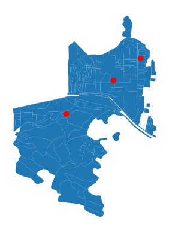

```python
# Run this cell to map your schools
A = blocks.plot()
schools.plot(ax=A, color="red")
plt.axis("off")
```

## Step 2: Optimization Model Preparation

> This section is to prepare the known information needed for our optimization model, and set parameters.

```python
# Tolerance is about how much you'd like to allow each school to deviate from the ideal capacity, which is the total number of students / the number of schools
TOLERANCE = 1.2 # 1.2 will allow schools to deviate by 20 %
```

#### Task: Set the I, J value correctly.

Things to consider.

- I is the total number of blocks
- J is the total number of schools

```python
I = len(blocks)
J = len(schools)
```

#### Task: Prepare $S_i$ and $N_i$ variables for the model.

$S_i$ must be an array of the elementary student population at each block  
$N_i$ must be an array of the elementary student population in minority race at each block

```python
S_i = blocks.elpop.reset_index(drop=True)
N_i = blocks.elpop.reset_index(drop=True) - blocks.elwpop.reset_index(drop=True)
```

#### Task: Prepare $C_j$ variable for the model.

$C_j$ indicates that it's an array. In that case, different capacity constraint is assigned to each school.  
However, for our convenience, let's do integer capacity this time.  
As we will set $C_j$ variable as an integer, let's use a notation, $C$.  
The $C$ integer value will be calculated by following steps.

1. The total elementary student population across the blocks
2. Divided by the number of schools (which is equal to J)
3. Multiplied by TOLERANCE

```python
C = (blocks.elpop.sum()/J) * TOLERANCE
```

#### Question 7: Prepare $D_{ij}$ variable for the model. ( 2 pts )

$D_{ij}$ represents a two-dimensional array with two subscripts, $i$ and $j$.

Considerations:

- The first subscript $i$ denotes the row index in the two-dimensional array, corresponding to a block with index $i$.
- The second subscript $j$ denotes the column index in the two-dimensional array, representing a school with index $j$.
  - For instance, if we have 100 blocks and 10 schools, $D_{ij}$ would be a two-dimensional array (or matrix) of shape (100, 10), consisting of 100 rows and 10 columns.
  - Consequently, $D_{ji}$ would be a matrix of shape (10, 100), containing 10 rows and 100 columns.
- $D_{ij}$ denotes that given a row index $i$ and column index $j$, a specific value can be retrieved, which represents the distance between the $i$th block and the $j$th school.
  - For example, $D_{12}$ would indicate the distance between the second block and the third school.

Given that, let's create the $D_ij$ variable.

```python
blocks["centroid"] = blocks["geometry"].centroid
```

```python
D_ij = np.array([[np.sqrt((blocks.centroid.iloc[i].x - schools.geometry.iloc[j].x)**2 +
                 (blocks.centroid.iloc[i].y - schools.geometry.iloc[j].y)**2)
         for j in range(J)] for i in range(I)])
```

```python
# Check the shape of your two-dimensional array, D_ij.
# It must match (I, J)

np.array(D_ij).shape, (I,J)
```

```
((177, 3), (177, 3))
```

#### Question 8: Choose upper and lower thresholds for the minority race fraction at each school and provide reasoning for your selection. ( 2 pts )

```python
total_share_minority = N_i.sum() / S_i.sum()
total_share_minority
```

```
0.5468975468975469
```

```python
FN_high = total_share_minority + 0.10
FN_low = total_share_minority - 0.10
```

**Write your answer in this markdown cell!**

With the minority share for the whole district coming out to about 55%, I am opting for an initial upper bound that is 10% higher than the total average, as well as a lower bound that is 10% lower than the average. This will prevent significant deviation from the population representation for the area. We will start with this and possibly expand the spread of the bounds around the average after initial results.

## Step 3: Optimization ( Wei et al., 2021 )

The model presented in the paper:

\begin{align*} \text{minimize} \quad & \sum_{i=1}^{I} \sum_{j=1}^{J} D_{ij} \cdot S_i \cdot x_{ij} \\ \text{subject to} \quad & \sum_{j=1}^{J} x_{ij} = 1 \quad \text{for } i = 1, \ldots, I \\ & \sum_{i=1}^{I} x_{ij} \cdot S_i \leq C_j \quad \text{for } j = 1, \ldots, J \\ & \sum_{i=1}^{I} (FN_{\text{low}} \cdot S_i - N_i) \cdot x_{ij} \leq 0 \quad \text{for } j = 1, \ldots, J \\ & \sum_{i=1}^{I} (N_i - FN_{\text{high}} \cdot S_i) \cdot x_{ij} \leq 0 \quad \text{for } j = 1, \ldots, J \\ & x_{ij} \in \{0,1\} \quad \text{for } i = 1, \ldots, I \text{ and } j = 1, \ldots, J \end{align*}

#### Question 9: Construct the School Districting Optimization Model using the provided skeleton code structure. ( 5 pts )

```python
model = gp.Model("School Districts")

# Create decision variables
x = model.addVars(I, J, vtype=GRB.BINARY, name="x")

# Set objective
model.setObjective(gp.quicksum(D_ij[i, j] * S_i[i] * x[i, j] for i in range(I) for j in range(J)), GRB.MINIMIZE)

# Add constraints
# Constraint 1
model.addConstrs(gp.quicksum(x[i,j] for j in range(J)) == 1 for i in range(I))
# Constraint 2
model.addConstrs(gp.quicksum(x[i,j] * S_i[i] for i in range(I)) <= C for j in range(J))
# Constraint 3
model.addConstrs(gp.quicksum((FN_low * S_i[i] - N_i[i]) * x[i,j] for i in range(I)) <= 0 for j in range(J))
# Constraint 4
model.addConstrs(gp.quicksum((N_i[i] - FN_high * S_i[i]) * x[i,j] for i in range(I)) <= 0 for j in range(J))

# Optimize model
model.optimize()
```

```
Gurobi Optimizer version 10.0.3 build v10.0.3rc0 (mac64[rosetta2])

CPU model: Apple M1 Pro
Thread count: 8 physical cores, 8 logical processors, using up to 8 threads

Academic license 2442811 - for non-commercial use only - registered to se___@bren.ucsb.edu
Optimize a model with 186 rows, 531 columns and 1566 nonzeros
Model fingerprint: 0x2e8f1bc2
Variable types: 0 continuous, 531 integer (531 binary)
Coefficient statistics:
  Matrix range     [6e-02, 4e+01]
  Objective range  [2e+02, 1e+05]
  Bounds range     [1e+00, 1e+00]
  RHS range        [1e+00, 3e+02]
Found heuristic solution: objective 1244963.6392
Presolve removed 62 rows and 186 columns
Presolve time: 0.00s
Presolved: 124 rows, 345 columns, 1380 nonzeros
Variable types: 0 continuous, 345 integer (345 binary)
Found heuristic solution: objective 840242.72443

Root relaxation: objective 6.108517e+05, 115 iterations, 0.00 seconds (0.00 work units)

    Nodes    |    Current Node    |     Objective Bounds      |     Work
 Expl Unexpl |  Obj  Depth IntInf | Incumbent    BestBd   Gap | It/Node Time

     0     0 610851.657    0    2 840242.724 610851.657  27.3%     -    0s
H    0     0                    611262.92274 610851.657  0.07%     -    0s
     0     0 610857.148    0    2 611262.923 610857.148  0.07%     -    0s
     0     0     cutoff    0      611262.923 611262.923  0.00%     -    0s

Explored 1 nodes (119 simplex iterations) in 0.03 seconds (0.00 work units)
Thread count was 8 (of 8 available processors)

Solution count 3: 611263 840243 1.24496e+06

Optimal solution found (tolerance 1.00e-04)
Best objective 6.112629227380e+05, best bound 6.112629227380e+05, gap 0.0000%
```

## Step 4: Application Result Visualization

Let's say.. We want to know what is the index of the largest value, 100, in list_a.  
We can convert list_a into np.array and use .argmax() to find the index!  
Then it returns the index of value, 100 in list_a, which is 7.  
It means it's 8th element. Do you agree?

```python
list_a = [1,2,3,4,5,6,7,100]
np.array(list_a).argmax()
```

```
7
```

#### Task: Use the argmax() function to find out which school index j, each block i is assigned to.

```python
# For hint, let's print out what values decision variables x have.
# Check if model solved it correctly.
    # Are all blocks assigned to only one school?
# If model solved it correctly, for each row in x matrix, finding the argmax will give the index of assigned school for each block.

for i in range(I):
    print(f"block {i}:", end=" ")
    for j in range(J):
        print(x[i,j].x, end=" ")
    print()
```

```
block 0: 1.0 0.0 0.0
block 1: -0.0 1.0 -0.0
block 2: -0.0 -0.0 1.0
block 3: 1.0 0.0 0.0
block 4: 1.0 0.0 0.0
block 5: -0.0 1.0 -0.0
block 6: 1.0 0.0 0.0
block 7: -0.0 -0.0 1.0
block 8: -0.0 -0.0 1.0
block 9: -0.0 1.0 -0.0
block 10: -0.0 -0.0 1.0
block 11: 1.0 0.0 0.0
block 12: -0.0 -0.0 1.0
block 13: -0.0 -0.0 1.0
block 14: -0.0 1.0 -0.0
block 15: -0.0 -0.0 1.0
block 16: 1.0 -0.0 -0.0
block 17: 1.0 0.0 0.0
block 18: 1.0 0.0 0.0
block 19: 1.0 0.0 0.0
block 20: 1.0 0.0 0.0
block 21: 1.0 0.0 0.0
block 22: -0.0 -0.0 1.0
block 23: 1.0 -0.0 -0.0
block 24: -0.0 -0.0 1.0
block 25: 1.0 0.0 0.0
block 26: 1.0 -0.0 -0.0
block 27: 1.0 0.0 0.0
block 28: -0.0 1.0 -0.0
block 29: 1.0 0.0 0.0
block 30: 1.0 0.0 0.0
block 31: -0.0 1.0 -0.0
block 32: -0.0 -0.0 1.0
block 33: 1.0 0.0 0.0
block 34: -0.0 1.0 -0.0
block 35: -0.0 -0.0 1.0
block 36: 1.0 0.0 0.0
block 37: 1.0 -0.0 -0.0
block 38: -0.0 -0.0 1.0
block 39: -0.0 -0.0 1.0
```

[output cut: 122 more lines]

```
block 162: 1.0 0.0 0.0
block 163: 1.0 -0.0 -0.0
block 164: 1.0 0.0 0.0
block 165: 1.0 0.0 0.0
block 166: -0.0 1.0 -0.0
block 167: -0.0 -0.0 1.0
block 168: -0.0 -0.0 1.0
block 169: -0.0 1.0 -0.0
block 170: -0.0 -0.0 1.0
block 171: 1.0 0.0 0.0
block 172: -0.0 -0.0 1.0
block 173: -0.0 -0.0 1.0
block 174: 1.0 0.0 0.0
block 175: -0.0 -0.0 1.0
block 176: -0.0 -0.0 1.0
```

```python
# Initialize an empty array to store the assigned school for each block.
assigned_school = []

# Iterate through each block
for i in range(I):  # Loop through each block index, i
    # Determine the school assignment for the current block i based on the optimization model solution.
    assigned_school.append(
        # Find the index (j) of the maximum value for each block i, indicating the assigned school.
        ###############PUT YOUR ANSWER HERE###############
        np.argmax([x[i, j].X for j in range(J)])
    )

# Create a new column in the blocks GeoDataFrame to indicate the assigned school for each block.
blocks["assigned_school"] = assigned_school
```

```python
# Start an empty array, to store the linestring connecting each block centroid to the assigned school
lines = []

# Iterate through each block, i
for i in range(I):
    j = assigned_school[i] # get the assigned school index, j
    line = LineString([blocks.centroid.iloc[i], schools.geometry.iloc[j]]) # Create a LineString with two points, ith block centroid and jth school
    lines.append(line)                                                                    # And append it to lines array.
```

```python
# Create a GeoDataFrame wtih the lines geometry,
# and add a column, "assigned_pop" with the number of students in each block.
line_pop = gpd.GeoDataFrame({"assigned_pop": S_i, "assigned_school": assigned_school}, geometry=lines)
```

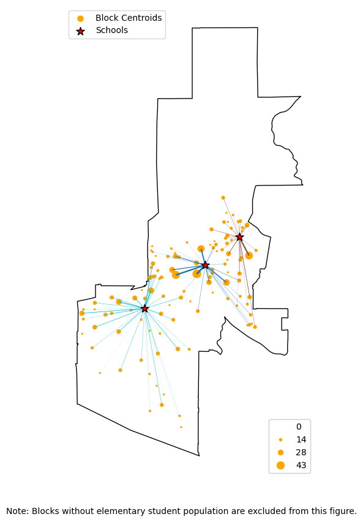

```python
# Plot the hope GeoDataFrame
A = hope.plot(facecolor="None", figsize=(10, 10))  # Plot the hope_ GeoSeries with specified facecolor and figure size

# Plot centroids of blocks with markersize proportional to elpop
blocks.centroid.plot(ax=A, markersize=blocks.elpop * 2, color="orange", label="Block Centroids")  # Plot centroids of blocks with markersize proportional to elpop, and assign a label for the legend

# Plot line_pop with linewidth proportional to assigned_pop
line_pop.plot("assigned_school", ax=A, linewidth=line_pop.assigned_pop / 20, categorical=True)  # Plot line_pop with linewidth proportional to assigned_pop

# Plot schools with custom marker style
schools.plot(ax=A, label="Schools", color="red", markersize=100, marker="*", zorder=100, edgecolor="black")  # Plot schools with custom marker style and assign a label for the legend

# Turn off axis
plt.axis("off")  # Turn off the axis for the plot

# Add legend for the plotted elements
plt.legend(loc=2)  # Add legend for the plotted elements with location specified

# Note to users about excluded blocks without elementary student population
plt.text(0.5, 0.05, "Note: Blocks without elementary student population are excluded from this figure.", ha='center', fontsize=10, transform=plt.gcf().transFigure)  # Add a note to the plot regarding excluded blocks

leg1 = A.get_legend()  # Get the legend for the first set of plotted elements

# Define bins for the legend indicating size
_, bins = pd.cut(blocks["elpop"], bins=3, precision=0, retbins=True)  # Define bins for the legend indicating size based on elpop values

# Create second legend indicating size
A.add_artist(
    A.legend(
        handles=[
            mlines.Line2D(
                [],
                [],
                color="orange",
                lw=0,
                marker="o",
                markersize=b / 5,
                label=str(int(b)),
            )
            for i, b in enumerate(bins)
        ],
        loc=4,
    )
)

# Restore the original legend
A.add_artist(leg1)

# Show the plot
plt.show()
```

#### Task: Convert the Coordiante System of the GeoDataFrames to 4326

This time, we will do figure with folium, to create an interactive map.  
For folium, all geographic datasets must be in crs with EPSG code: 4326. (https://epsg.io/4326)  
Let's convert all GeoDataFrames into the 4326 crs.

```python
blocks_4326 = blocks.to_crs("epsg:4326")
hope_4326 =hope.to_crs("epsg:4326")
schools_4326 = schools.to_crs("epsg:4326")
line_pop_4326 = line_pop.set_crs("epsg:4326", inplace=True)
```

```python
# Create a Folium Map object with specified location, tiles, zoom level, and scale control
m = folium.Map(location=[blocks_4326.unary_union.centroid.y, blocks_4326.unary_union.centroid.x], tiles="Cartodb Positron", zoom_start=15, control_scale=True)

# Convert GeoDataFrame to GeoJSON
hope_geojson = hope_4326.to_json()

# Add GeoJSON layer for hope_ with specified name and tooltip, and style function to control appearance
folium.GeoJson(
    hope_geojson,
    name='Hope Elementary School District',
    tooltip='Hope Elementary School District',
    style_function=lambda x: {'color': 'black', 'fillColor': 'None', 'weight': 1}
).add_to(m)

# Add markers for centroids of blocks
for idx, row in blocks_4326.loc[blocks_4326.elpop > 0].iterrows():
    # Create circle markers for centroids of blocks with popup information
    school_name = schools_4326.loc[row.assigned_school, 'SchoolName'] if row.assigned_school in schools_4326.index else 'Unknown'
    folium.CircleMarker(
        location=[row.geometry.centroid.y, row.geometry.centroid.x],
        radius=row.elpop / 2,  # Adjust the factor to control marker size
        popup=f"Block ID: {row.GEOID20}, <br><br> ElPop: {row.elpop} <br><br> AssignedTo: {school_name}",
        fill=True,
        color='orange',
        fill_opacity=0.6,
        fill_color='orange'
    ).add_to(m)

# Add markers for schools
for idx, row in schools_4326.iterrows():
    folium.Marker(
        location=[row.geometry.y, row.geometry.x],
        popup=f"{row.SchoolName}",
    ).add_to(m)

# Helper function to generate style function with specified color
def style_function(color):
    return lambda x: {
        'color': color,
        'weight': x['properties']['assigned_pop'] / 10,
    }

# Add line_pop as a GeoJSON layer with specified name and style function
for j in range(J):
    if j == 0:
        color = "blue"
    elif j == 1:
        color = "brown"
    else:
        color = "skyblue"

    line_pop_geojson = line_pop_4326.loc[line_pop_4326.assigned_school == j].reset_index(drop=True).to_json()
    folium.GeoJson(
        line_pop_geojson,
        name=f'line_pop_{j}',
        style_function=style_function(color)  # Use the helper function to generate the style function
    ).add_to(m)

# Display the map
m  # This line displays the map
```

Make this Notebook Trusted to load map: File -> Trust Notebook

[interactive chart not shown]

## Step 5: Result Evaluation

```python
# Let's gather current districting information

curr_hope = gpd.read_file("Data/digitized_current_districts.shp")
curr_dist_school_map = {0:2, 1:0, 2:1}

curr_assigned = []

for block in blocks.geometry:
    max_inter_dist_index = block.intersection(curr_hope.geometry).area.argmax()
    cur_assgined_school_j = curr_dist_school_map[max_inter_dist_index]
    curr_assigned.append(cur_assgined_school_j)

blocks["curr_assigned"] = curr_assigned
```

```python
def evaluate_assignment(col="curr_assigned"):
    popsums = []
    FNs = []
    Travel_ds = []

    for j in range(J):
        school_blocks = blocks.loc[blocks[col] == j]
        popsum = school_blocks.elpop.sum()
        wsum = school_blocks.elwpop.sum()
        if popsum == 0:
            FNs.append(np.nan)
            Travel_ds.append(np.nan)
            popsums.append(0)
            continue
        FNs.append((1 - wsum / popsum) * 100)
        popsums.append(popsum)

        Travel_d = 0
        for i in school_blocks.index:
            if i >= I or j >= J:
                print(f"Index out of bounds: i={i}, j={j}")
                continue
            Travel_d += D_ij[i, j] * S_i[i]
        Travel_ds.append(Travel_d / popsum)

    print(f"Mean Travel Distance (m) is {np.mean([d for d in Travel_ds if not np.isnan(d)])}")
    return pd.DataFrame({'School': schools.SchoolName, 'Capacity': popsums, 'FN': FNs, "Travel_ds (m)": Travel_ds})


evaluate_assignment("curr_assigned").round(2)
```

[output not shown]

[output cut: 47 more lines]

[output not shown]

|  | School | Capacity | FN | Travel_ds (m) |
| --- | --- | --- | --- | --- |
| 8241 | Hope Elementary | 136 | 57.35 | 1100.59 |
| 8242 | Monte Vista Elementary | 230 | 53.48 | 470.65 |
| 8243 | Vieja Valley Elementary | 327 | 54.43 | 1301.64 |

```python
evaluate_assignment(col = "assigned_school").round(2)
```

[output not shown]

[output cut: 47 more lines]

[output not shown]

|  | School | Capacity | FN | Travel_ds (m) |
| --- | --- | --- | --- | --- |
| 8241 | Hope Elementary | 271 | 64.58 | 1125.04 |
| 8242 | Monte Vista Elementary | 169 | 44.97 | 384.71 |
| 8243 | Vieja Valley Elementary | 253 | 50.59 | 565.14 |

```python
# Import the random module for generating random numbers
import random

# Set the seed to ensure reproducibility of random numbers
random.seed(1)

# Generate random assignments for each block to one of the three schools
blocks["assigned_random"] = random.choices(range(3), k=len(blocks))

# Evaluate the random assignment and display the results, rounding to two decimal places
evaluate_assignment(col="assigned_random").round(2)
```

[output not shown]

[output cut: 47 more lines]

[output not shown]

|  | School | Capacity | FN | Travel_ds (m) |
| --- | --- | --- | --- | --- |
| 8241 | Hope Elementary | 174 | 63.22 | 857.56 |
| 8242 | Monte Vista Elementary | 239 | 44.77 | 731.87 |
| 8243 | Vieja Valley Elementary | 280 | 57.86 | 1360.28 |

You can discuss about..

- Minority Fraction bounds
- Capacity constraints
- Distance metric
- and so on!

**Write your answer in this markdown cell!**

The new results actually create more minority variability in the data than existed in the original assignments, which is surprising at first though it became clear that the original assignments were very close in their minority shares before this exercise. What our model did accomplish is lower travel distance compared to the original assignment, at least for two of the 3 schools. For Viejo Valley the travel distance is significantly reduced.